# Analysing Dengue Cases in Singapore

Shayne, Roscoe, Anu

26 July 2020

# Analysing Dengue Cases in Singapore

## Problem Statement

Dengue fever is a vector-borne infectious disease that is endemic in the tropical world. Singapore is one of several countries with high disease burden of dengue. In 2020, Singapore saw 1,158 dengue cases in a week of June - the highest number of weekly dengue cases ever recorded since 2014. Why is there a sudden spike in dengue cases this year?

In our Capstone Project, we ask two questions about potential factors affecting dengue cases. Our questions are not confirmatory in nature; rather, they are exploratory.

1. Does atmospheric variables influence the incidence of dengue cases? Specifically, is higher humidity, precipitation, or temperature associated with increased numbers of dengue cases?
2. Do local factors explain the different number of cases in different regions of Singapore?

For our data science project, we activated the following packages, using the `Tidyverse` approach.

```r
# Rule for activating packages in development mode:
# - Only activate ggfortify, ggmap, ggplot2 (notice a pattern?) and magrittr
# - Full specifications for everything else, for now
#
# For deployment mode, activate every package that is referenced more than once
# - Add package name here, then use find-and-replace to remove "<package>::"
# - Allowed to activate tidyverse
#   - Remember what are the 8 packages?

pacman::p_load(
  ggfortify,
  # ggmap,
  ggplot2,
  magrittr
  # tidyverse
)
```

## Import

Then, we imported our dataset.

> The most time-consuming component of data science? This might take a while.

We work towards 2 separate datasets: `data_time` for temporal analysis, and `data_space` for spatial analysis. They will only be fully available after the tidy and transform process since there’s quite a bit of aggregating and joining involved.

We start with 7 raw datasets.

The main sources are:  
1. [Data.gov.sg](https://data.gov.sg/)  
2. [MOH Weekly Infectious Disease Bulletin](https://www.moh.gov.sg/resources-statistics/infectious-disease-statistics/2020/weekly-infectious-diseases-bulletin)  
3. [MOH Healthcare Institutions Directory](http://hcidirectory.sg/hcidirectory/)  
4. [MSS Historical Daily Weather Records](http://www.weather.gov.sg/climate-historical-daily/)

[Click here](https://github.com/roscoelai/dasr2020capstone#data) for a summary page.

The full glorious details of their providence are given below. Unfortunately, the source code has been arranged with functional considerations in mind, and may not be in chronological order.

```r
# These functions are mandatory (for importing raw data)

import_moh_weekly <- function(url_or_path) {
  #' Weekly Infectious Diseases Bulletin
  #'
  #' @description
  #' Weekly infectious diseases bulletin from the Ministry of Health (MOH).
  #' Data from 2012-W01 to 2020-W29 (as of 24 July 2020). Relevant links are
  #' given under details.
  #'
  #' @details
  #' \href{https://www.moh.gov.sg/resources-statistics/infectious-disease-statistics/2020/weekly-infectious-diseases-bulletin}{MOH Weekly Infectious Disease Bulletin}
  #'
  #' \href{https://www.moh.gov.sg/docs/librariesprovider5/diseases-updates/weekly-infectious-disease-bulletin-year-202071e221d63d4b4be0aa2b03e9c5e78ac2.xlsx}{Latest data as of 24 July 2020 (2012-W01 to 2020-W29)}
  #'
  #' \href{https://raw.githubusercontent.com/roscoelai/dasr2020capstone/master/data/moh/weekly-infectious-disease-bulletin-year-202071e221d63d4b4be0aa2b03e9c5e78ac2.xlsx}{Backup copy as of 24 July 2020 (2012-W01 to 2020-W29)}
  #'
  #' @param url_or_path The URL or file path of the .xlsx file.
  #' @return Weekly infectious diseases bulletin (2012-W01 to 2020-W29).

  # Columns will be renamed to follow 2020
  colnames_2020 = c(
    "Campylobacter enterosis" = "Campylobacter enteritis",
    "Campylobacterenterosis" = "Campylobacter enteritis",
    "Campylobacteriosis" = "Campylobacter enteritis",
    "Chikungunya Fever" = "Chikungunya",
    "Dengue Haemorrhagic Fever" = "DHF",
    "Dengue Fever" = "Dengue",
    "Hand, Foot and Mouth Disease" = "HFMD",
    "Hand, Foot Mouth Disease" = "HFMD",
    "Nipah virus infection" = "Nipah",
    "Viral Hepatitis A" = "Acute Viral Hepatitis A",
    "Viral Hepatitis E" = "Acute Viral Hepatitis E",
    "Zika Virus Infection" = "Zika",
    "Zika virus infection" = "Zika"
  )

  # Check if the given path is a URL by trying to download to a temp file. If
  #   successful, return the temp file. If not, return the original path.
  xlsx_file = tryCatch({
    temp = tempfile(fileext = ".xlsx")
    download.file(url_or_path, destfile = temp, mode = "wb")
    temp
  }, error = function(e) {
    url_or_path
  })

  xlsx_file %>%
    readxl::excel_sheets() %>%
    lapply(function(sheetname) {
      df = readxl::read_xlsx(xlsx_file, sheetname, skip = 1)

      # Date formats are different for 2020
      if (sheetname == "2020") {
        df$Start = lubridate::dmy(df$Start)
        df$End = lubridate::dmy(df$End)
      }

      # Find and rename columns that need to be renamed
      mapper = na.omit(colnames_2020[names(df)])
      dplyr::rename_with(df, ~mapper, names(mapper))
    }) %>%
    dplyr::bind_rows() %>%
    dplyr::rename(Epiweek = `Epidemiology Wk`) %>%
    dplyr::mutate(Epiyear = lubridate::epiyear(Start)) %>%
    dplyr::select(Epiyear, everything()) %>%
    dplyr::arrange(Start)
}

read_kmls <- function(url_or_path) {
  # There are (at least) 2 approaches to handling .kml data:
  # 1. sp - rgdal::readOGR()
  # 2. sf - sf::st_read()
  #
  # The sp approach was quickly abandoned as their objects were rather complex
  #   and did not facilitate method chaining.
  #
  # The sf approach produced objects that look like data.frames, which aided
  #   method chaining, but had their own peculiarities:
  #   - Dimension: set to XY using sf::st_zm()
  #   - Geographic CRS: use sf::`st_crs<-`("WGS84") World Geodetic Survey 1984

  # Check if the given paths are URLs by trying to download to temp files. If
  #   successful, return the temp files. If not, return the original paths.
  kml_files = tryCatch({
    temp = tempfile(fileext = rep(".kml", length(url_or_path)))
    Map(function(x, y) download.file(x, y, mode = "wb"), url_or_path, temp)
    temp
  }, error = function(e) {
    url_or_path
  })

  kml_files %>%
    lapply(sf::st_read, quiet = T) %>%
    dplyr::bind_rows() %>%
    tibble::as_tibble() %>%
    sf::st_as_sf() %>%
    sf::st_zm()
}
```

### Load raw data into memory (the easy)

> If the data files are available locally, set `online_repo = F` for faster loading. Otherwise, the function will read .csv files directly from the URLs while other file formats will be downloaded to a temporary folder.

```r
grand_import_no_webscraping <- function(online_repo = TRUE) {
  # Allow user to choose whether to import raw data from an online repository
  #   or from local files.

  if (online_repo) {
    fld = paste0("https://raw.githubusercontent.com/roscoelai/",
                 "dasr2020capstone/master/data/")
  } else {
    # Check that the "../data/ folder exists
    assertthat::assert_that(dir.exists("../data/"),
                            msg = 'Unable to locate "../data/" directory.')
    fld = "../data/"
  }

  list(
    "moh_bulletin" = import_moh_weekly(paste0(
      fld, "moh/weekly-infectious-disease-bulletin-year-2020.xlsx"
    )),

    "mss_19stations" = readr::read_csv(paste0(
      fld, "mss/mss_daily_2012_2020_19stations_20200726.csv"
    )),

    "hci_clinics" = readr::read_csv(paste0(
      fld, "hcid/hci_clinics_20200725.csv"
    )),

    "planning_areas" = read_kmls(paste0(
      fld, "kmls/plan-bdy-dwelling-type-2017.kml"
    )),

    "dengue_polys" = read_kmls(paste0(
      fld, "kmls/denguecase-", c("central",
                                 "northeast",
                                 "southeast",
                                 "southwest"), "-area.kml"
    )),

    "aedes_polys" = read_kmls(paste0(
      fld, "kmls/breedinghabitat-", c("central",
                                      "northeast",
                                      "northwest",
                                      "southeast",
                                      "southwest"), "-area.kml"
    )),

    "mss_63station_pos" = readr::read_csv(paste0(
      fld, "mss/Station_Records.csv"
    ))
  )
}

raw_data <- grand_import_no_webscraping(online_repo = T)
```

### Import data *de novo* (where available)

> Use this if you have too much time. The following code chunk is disabled, but is provided here to show how the data can be derived from the primary sources (where available). The non-essential functions have been dumped here. Using this code chunk would require a valid Google Maps Platform API key.

```r
import_mss_daily <- function(years, stations = NULL) {
  #' Historical Daily Weather Records
  #'
  #' @description
  #' Daily weather records from the Meteorological Service Singapore (MSS).
  #' Available data ranges from January 1980 to June 2020. Only 19 of the 63
  #' climate stations are recognized by this function, because these contain
  #' more than just rainfall data. Relevant links are given under details.
  #'
  #' MSS is nice enough to have their data in .csv files, with a systematic
  #' naming scheme. Data compilation becomes as simple as generating the
  #' appropriate list of URLs.
  #'
  #' @details
  #' \href{http://www.weather.gov.sg/climate-historical-daily/}{MSS Daily Records}
  #'
  #' \href{http://www.weather.gov.sg/wp-content/uploads/2016/12/Station_Records.pdf}{List of stations, weather parameters and periods of records}
  #'
  #' @param years A vector of the years of interest.
  #' @param stations A vector of the climate station names.
  #' @return Combined daily weather records.
  #' @examples
  #' import_mss_daily(2012:2020, "Changi")
  #' import_mss_daily(2012:2020, c("Changi", "Clementi", "Khatib", "Newton"))

  stations_lookup = c(
    "Admiralty" = "104_",
    "Ang Mo Kio" = "109_",
    "Changi" = "24_",
    "Choa Chu Kang (South)" = "121_",
    "Clementi" = "50_",
    "East Coast Parkway" = "107_",
    "Jurong (West)" = "44_",
    "Jurong Island" = "117_",
    "Khatib" = "122_",
    "Marina Barrage" = "108_",
    "Newton" = "111_",
    "Pasir Panjang" = "116_",
    "Pulau Ubin" = "106_",
    "Seletar" = "25_",
    "Sembawang" = "80_",
    "Sentosa Island" = "60_",
    "Tai Seng" = "43_",
    "Tengah" = "23_",
    "Tuas South" = "115_"
  )

  # Check that all provided station names are in the list, if not, exit and
  #   print out the list (of names) for the user.
  mask = !(stations %in% names(stations_lookup))
  if (any(mask)) {
    stop("The following station names are not recognized:\n",
         paste(stations[mask], collapse = "\n"),
         "\n\nPlease select from the following:\n",
         paste(names(stations_lookup), collapse = "\n"))
  }

  # If no station names specified, take the full list
  if (is.null(stations)) {
    station_nums = stations_lookup
  } else {
    station_nums = stations_lookup[stations]
  }

  # The URL to each .csv file has the following format:
  # - "<url_base><station number>_<YYYY><MM>.csv"
  # - Notice the station numbers given above contain the "_" suffix
  url_base = "http://www.weather.gov.sg/files/dailydata/DAILYDATA_S"

  # To enumerate all the URLs, take the Cartesian product of:
  # - station numbers
  # - years
  # - months (we'll always attempt to find all 12 months)
  #
  # Flatten the result into a vector, then prefix and suffix with `url_base`
  #   and ".csv", respectively.

  # Base R
  urls = station_nums %>%
    outer(years, FUN = paste0) %>%
    outer(sprintf("%02d", 1:12), FUN = paste0) %>%
    sort() %>%  # Flatten and arrange in alphabetical order
    paste0(url_base, ., ".csv")

  # Equivalent tidyverse approach (for reference)
  # urls = station_nums %>%
  #   tidyr::crossing(years, sprintf("%02d", 1:12)) %>%
  #   tidyr::unite("station_year_month", sep = "") %>%
  #   dplyr::pull() %>%
  #   paste0(url_base, ., ".csv")

  # We have a list of URLs, but some of them may not exist (some stations do
  #   not have data for some months). Use tryCatch() to return a table for the
  #   URLs that exist, and a NA for those that don't.
  #
  # Problems with multibyte characters and countermeasures:
  # - Some colnames contained the "degree sign" symbol which somehow made the
  #   table contents inaccessible. Tables after April 2020 had slightly
  #   different colnames.
  #   - Manually set the colnames for each table.
  # - Some tables contained the "em dash" symbol to indicate missing values.
  #   - They will be coerced to NA when the columns are type cast to numeric.
  #   - There will be warning messages.
  dfs = urls %>%
    lapply(function(url) {
      tryCatch({
        df = readr::read_csv(url,
                             skip = 1,
                             col_names = c(
                               "Station",
                               "Year",
                               "Month",
                               "Day",
                               "Rainfall",
                               "Highest_30_min_rainfall",
                               "Highest_60_min_rainfall",
                               "Highest_120_min_rainfall",
                               "Mean_temp",
                               "Max_temp",
                               "Min_temp",
                               "Mean_wind",
                               "Max_wind"
                             ),
                             col_types = readr::cols_only(
                               "Station" = "c",
                               "Year" = "n",
                               "Month" = "n",
                               "Day" = "n",
                               "Rainfall" = "n",
                               "Mean_temp" = "n",
                               "Max_temp" = "n",
                               "Min_temp" = "n"
                             ))

        # Announce progress (UX is important! We can tolerate lower efficiency)
        message(paste(df[1, 1:3], collapse = "_"))

        df
      }, error = function(e) {
        NA
      })
    })

  dfs[!is.na(dfs)] %>%
    dplyr::bind_rows() %>%
    dplyr::arrange(Station, Year, Month, Day)
}

import_hcidirectory <- function() {
  #' Healthcare Institutions Directory
  #'
  #' @description
  #' The \href{http://hcidirectory.sg/hcidirectory/}{Healthcare Institutions
  #' (HCI) Directory}, an initiative by the Ministry of Health (MOH), is a
  #' platform for all HCIs licensed under the Private Hospitals and Medical
  #' Clinics (PHMC) Act to provide information about their services and
  #' operations to the public.
  #'
  #' This function is custom-made to consolidate the names and addresses of
  #' HCIs which are medical clinics that offer general medical services.
  #'
  #' The HCI Directory is a dynamic web page, so using RSelenium might be
  #' required.
  #'
  #' @return The names and addresses of selected HCIs.
```

```r
  # Run a Selenium Server using `RSelenium::rsDriver()`. The parameters e.g.
  #   `browser`, `chromever` (or `geckover` if using Firefox, or other drivers
  #   if using other browsers) have to be properly set. Trial-and-error until a
  #   configuration works. Set `check = T` the very first time it's run on a
  #   system, then set `check = F` after that to speed things up.
  rD = RSelenium::rsDriver(browser = "chrome",
                           chromever = "83.0.4103.39",
                           check = F)

  # Connect to server with a remoteDriver instance.
  remDr = rD$client

  # Set timeout on waiting for elements
  remDr$setTimeout(type = "implicit", milliseconds = 10000)

  # Navigate to the given URL
  remDr$navigate("http://hcidirectory.sg/hcidirectory/")

  # Click 4 things:
  # 1. "MORE SEARCH OPTIONS"
  # 2. "Medical Clinics Only"
  # 3. "General Medical"
  # 4. "Search"
  c(
    "options" = "#moreSearchOptions",
    "medclins" = "#criteria > table > tbody > tr:nth-child(2) > td > label",
    "genmed" = "#isGenMed",
    "search" = "#search_btn_left"
  ) %>%
    lapply(remDr$findElement, using = "css") %>%
    purrr::walk(function(elem) elem$clickElement())

  # Find the number of pages
  results = remDr$findElement("#results", using = "css")
  npages = results$getElementAttribute("innerHTML")[[1]] %>%
    xml2::read_html() %>%
    rvest::html_node("#totalPage") %>%
    rvest::html_attr("value") %>%
    as.numeric()

  # Create an empty tibble to append results
  df = tibble::tibble(
    id = character(),
    name = character(),
    add = character()
  )

  i = 1
  while (T) {
    results = remDr$findElement("#results", using = "css")
    html = results$getElementAttribute("innerHTML")[[1]] %>%
      xml2::read_html()

    # Determine the index numbers of the (up to 10) results on the page
    idx = html %>%
      # Find the element that says "SHOWING 1 - 10 OF 1,761 RESULTS"
      rvest::html_nodes(".col1") %>%
      .[1] %>%
      rvest::html_text() %>%
      # Commas have to be eliminated for numbers > 999
      gsub(",", "", .) %>%
      # Find the smallest and largest numbers and apply the colon operator
      sub(".*Showing\\s+(.*)\\s+of.*", "\\1", .) %>%
      strsplit(split = " - ") %>%
      unlist() %>%
      as.numeric() %>%
      { .[1]:.[2] }

    # Only append results if IDs are not in the table
    if (!any(idx %in% df$id)) {
      df = df %>%
        dplyr::bind_rows(
          html %>%
            # Find both the name and address nodes
            rvest::html_nodes(".name,.add") %>%
            rvest::html_text() %>%
            # Tidy whitespace
            gsub("\\s+", " ", .) %>%
            trimws() %>%
            # Concatenate IDs, odd rows (names), and even rows (addresses)
            { cbind(idx, .[c(TRUE,FALSE)], .[!c(TRUE,FALSE)]) } %>%
            tibble::as_tibble() %>%
            setNames(c("id", "name", "add"))
        )

      # Announce progress and increment page counter
      message(i, " of ", npages, " done (", round(i / npages * 100, 2), "%)")
      i = i + 1
    }

    # Natural exit point
    if (i > npages) break

    # Navigate to the next page (if available, else stop)
    the_end = tryCatch({
      nextpage = remDr$findElement("#PageControl > div.r_arrow", using = "css")
      nextpage$clickElement()
      F
    }, error = function(e) {
      print(paste("There are no more pages after", i))
      T
    })

    # Unnatural exit point
    if (the_end) break
  }

  # Clean up RSelenium
  remDr$close()
  rD[["server"]]$stop()
  rm(rD, remDr)
  gc()

  # Kill Java instance(s) inside RStudio
  # docs.microsoft.com/en-us/windows-server/administration/windows-commands/taskkill
  system("taskkill /im java.exe /f", intern = F, ignore.stdout = F)

  # Clean up:
  # - Franchises may have the same name with different addresses
  # - Different practices may have the same zipcodes and even buildings
  # - We will consider each full address unique, and a single practice

  # Clean up duplicate addresses
  df %>%
    .[!duplicated(tolower(.$add), fromLast = T),]
}

zipcodes_to_geocodes <- function(zipcodes) {
  #' Get Geo-location from Google Maps
  #'
  #' @description
  #' Attempt to obtain the longitudes, latitudes, and addresses of the given
  #' zipcodes using ggmap::geocode().
  #'
  #' @param zipcodes A vector of zipcodes.
  #' @return Geo-location data of the associated zipcodes.

  # Prompt user to input API key
  ggmap::register_google(key = readline("Please enter Google API key: "))

  # Create an (almost) empty tibble to append results
  res = zipcodes %>%
    # Remove duplicates to minimize number of requests
    .[!duplicated(.)] %>%
    tibble::as_tibble() %>%
    dplyr::rename(zip = value) %>%
    dplyr::mutate(lon = NA_real_,
                  lat = NA_real_,
                  address = NA_character_)

  for (i in 1:nrow(res)) {
    result = tryCatch({
      ggmap::geocode(res$zip[i], output = "latlona", source = "google")
    }, warning = function(w) {
      w$message
    }, error = function(e) {
      NA
    })

    # If the registered key is invalid, there's no point continuing
    if (grepl("The provided API key is invalid", result[1], fixed = T)) {
      stop("A valid Google API key is required.")
    }

    # A useful result will have something, and will have names
    if (!is.na(result) && !is.null(names(result))) {
      res$lon[i] = result$lon
      res$lat[i] = result$lat
      res$address[i] = result$address
    }

    # Announce progress
    message(i, " of ", nrow(res), " (",round(i / nrow(res) * 100, 2), "%)")
  }

  res
}

grand_import_de_novo <- function() {
  # This might take a while, and requires a Google Maps Platform API key

  list(
    "moh_bulletin" = import_moh_weekly(paste0(
      "https://www.moh.gov.sg/docs/librariesprovider5/diseases-updates/",
      "weekly-infectious-disease-bulletin-year-2020",
      "71e221d63d4b4be0aa2b03e9c5e78ac2.xlsx"
    )),

    "mss_19stations" = import_mss_daily(years = 2012:2020),
```

```r
    "hci_clinics" = import_hcidirectory() %>%
      dplyr::mutate(zip = sub(".*((?i)singapore\\s+\\d+).*", "\\1", add)) %>%
      # Requires Google Maps Platform API key
      dplyr::left_join(zipcodes_to_geocodes(.$zip), by = "zip") %>%
      dplyr::select(-id, -zip, -address) %>%
      tidyr::drop_na(),

    "planning_areas" = read_kmls(paste0(
      "https://geo.data.gov.sg/plan-bdy-dwelling-type-2017/2017/09/27/kml/",
      "plan-bdy-dwelling-type-2017.kml"
    )),

    "dengue_polys" = read_kmls(
      c("central", "northeast", "southeast", "southwest") %>%
        paste0("https://geo.data.gov.sg/denguecase-", .,
               "-area/2020/07/17/kml/denguecase-", ., "-area.kml")
    ),

    "aedes_polys" = read_kmls(c(
      c("central", "northeast", "northwest") %>%
        paste0("https://geo.data.gov.sg/breedinghabitat-", .,
               "-area/2020/07/17/kml/breedinghabitat-", ., "-area.kml"),
      c("southeast", "southwest") %>%
        paste0("https://geo.data.gov.sg/breedinghabitat-", .,
               "-area/2020/07/23/kml/breedinghabitat-", ., "-area.kml")
    )),

    "mss_63station_pos" = readr::read_csv(paste0(
      "https://raw.githubusercontent.com/roscoelai/dasr2020capstone/master/",
        "data/mss/Station_Records.csv"
    ))
  )
}

# raw_data <- grand_import_de_novo()
```

### A quick and dirty overview of the raw data

```r
names(raw_data)
```

```
[1] "moh_bulletin"      "mss_19stations"    "hci_clinics"
[4] "planning_areas"    "dengue_polys"      "aedes_polys"
[7] "mss_63station_pos"
```

```r
raw_data %>%
  purrr::walk(dplyr::glimpse)
```

```
Rows: 470
Columns: 46
$ Epiyear                                    <dbl> 2012, 2012, 2012, 2012, ...
$ Epiweek                                    <dbl> 1, 2, 3, 4, 5, 6, 7, 8, ...
$ Start                                      <dttm> 2012-01-01, 2012-01-08,...
$ End                                        <dttm> 2012-01-07, 2012-01-14,...
$ Cholera                                    <dbl> 0, 0, 0, 0, 0, 0, 0, 0, ...
$ Paratyphoid                                <dbl> 1, 1, 1, 1, 3, 2, 1, 4, ...
$ Typhoid                                    <dbl> 6, 3, 5, 1, 5, 0, 2, 3, ...
$ `Acute Viral Hepatitis A`                  <dbl> 1, 2, 3, 3, 2, 0, 0, 0, ...
$ `Acute Viral Hepatitis E`                  <dbl> 3, 0, 0, 2, 0, 4, 2, 3, ...
$ Poliomyelitis                              <dbl> 0, 0, 0, 0, 0, 0, 0, 0, ...
$ Plague                                     <dbl> 0, 0, 0, 0, 0, 0, 0, 0, ...
$ `Yellow Fever`                             <dbl> 0, 0, 0, 0, 0, 0, 0, 0, ...
$ Dengue                                     <dbl> 74, 64, 60, 50, 84, 87, ...
```

[output cut: 75 more lines]

## Tidy & Transform

> The tidying process can (ironically) be tidied. It takes too long to get to `data_space`. Relook the flow of logic. And too many reassignments!

### It is relatively straightforward to get `data_time`.

```r
# TODO: Can we avoid reassignment?
# There are 2 options:
# 1. Incorporate into webscraping process
# 2. Incorporate into import (there will be 2 duplicates)
raw_data$mss_19stations <- raw_data$mss_19stations %>%
  dplyr::mutate(
    # Calculate daily temperature range
    Temp_range = Max_temp - Min_temp,
    # Calculate epidemiological years and weeks
    Date = lubridate::ymd(paste(Year, Month, Day, sep = "-")),
    Epiyear = lubridate::epiyear(Date),
    Epiweek = lubridate::epiweek(Date),
    .keep = "unused"
  )

# Minimize size of datasets, choose "easier" column names
data_time <- raw_data$moh_bulletin %>%
  dplyr::select(Epiyear:End,
                Dengue,
                HFMD,
                `Acute Upper Respiratory Tract infections`,
                `Acute Diarrhoea`) %>%
  dplyr::rename(URTI = `Acute Upper Respiratory Tract infections`,
                Diarrhoea = `Acute Diarrhoea`) %>%
  tidyr::drop_na() %>%
  dplyr::left_join(
    raw_data$mss_19stations %>%
      # Aggregation schema (up to 19 stations x up to 7 days -> 1 value)
      dplyr::group_by(Epiyear, Epiweek) %>%
      dplyr::summarise(Mean_rainfall = mean(Rainfall, na.rm = T),
                       Med_rainfall = median(Rainfall, na.rm = T),
                       Mean_temp = mean(Mean_temp, na.rm = T),
                       Med_temp = median(Mean_temp, na.rm = T),
                       Mean_temp_rng = mean(Temp_range, na.rm = T),
                       Med_temp_rng = median(Temp_range, na.rm = T),
                       .groups = "drop"),
    by = c("Epiyear", "Epiweek")
  )
```

### On the other hand, `data_space` requires **a lot** more wrangling.

```r
data <- list(
  "dengue_points" = raw_data$dengue_polys %>%
    dplyr::mutate(n = as.numeric(sub(".*: (\\d+).*", "\\1", Description))) %>%
    sf::st_centroid() %>%
    .[rep(1:nrow(.), .$n),] %>%
    dplyr::select(-Name, -Description, -n),

  "aedes_points" = raw_data$aedes_polys %>%
    dplyr::mutate(n = as.numeric(sub(".*: (\\d+).*", "\\1", Description))) %>%
    sf::st_centroid() %>%
    .[rep(1:nrow(.), .$n),] %>%
    dplyr::select(-Name, -Description, -n),

  "clinic_points" = raw_data$hci_clinics %>%
    sf::st_as_sf(coords = c("lon", "lat")) %>%
    sf::`st_crs<-`("WGS84"),

  "weather_points" = raw_data$mss_19stations %>%
    dplyr::filter(Epiyear == 2020) %>%
    # Filter for the last 3 weeks
    dplyr::filter(Epiweek > max(Epiweek) - 3) %>%
    # Aggregation schema (up to 7 days x up to 3 weeks -> 1 value)
    dplyr::group_by(Station) %>%
    dplyr::summarise(mean_rainfall = mean(Rainfall, na.rm = T),
                     med_rainfall = median(Rainfall, na.rm = T),
                     mean_temp = mean(Mean_temp, na.rm = T),
                     med_temp = median(Mean_temp, na.rm = T),
                     mean_temp_rng = mean(Temp_range, na.rm = T),
                     med_temp_rng = median(Temp_range, na.rm = T)) %>%
    tidyr::drop_na() %>%
    dplyr::left_join(
      raw_data$mss_63station_pos %>%
        sf::st_as_sf(coords = c("Long. (E)", "Lat.(N)")) %>%
        sf::`st_crs<-`("WGS84") %>%
        dplyr::select(Station),
      by = "Station"
    ) %>%
    sf::st_as_sf(),

  "planning_areas" = raw_data$planning_areas %>%
    dplyr::bind_cols(
      # Extract data from HTML in the Description column (dwelling types)
      .$Description %>%
        lapply(function(x) {
        xml2::read_html(x) %>%
          rvest::html_node("table") %>%
          rvest::html_table() %>%
          t() %>%
          `colnames<-`(.[1,]) %>%
          .[2, 1:10]
        }) %>%
        dplyr::bind_rows()
    ) %>%
    dplyr::select(-Name, -Description) %>%
    dplyr::rename_all(tolower) %>%
    dplyr::rename(plan_area = pln_area_n,
                  pop = total) %>%
    dplyr::mutate(plan_area = tools::toTitleCase(tolower(plan_area)),
                  dplyr::across(pop:others, as.numeric),
                  area_km2 = units::set_units(sf::st_area(.), km^2)) %>%
    tibble::as_tibble() %>%
    sf::st_as_sf()
)

idw_interpolation <- function(points, polys, ordinal = 2) {
  # Inverse-distance-weighted interpolation
  weights = polys %>%
    sf::st_centroid() %>%
    sf::st_distance(points) %>%
    # Small ordinal: Unweighted average
    # Large ordinal: Proximity (Thiessen) interpolation
    { 1 / (. ^ ordinal) }

  values = points %>%
    as.data.frame() %>%
    dplyr::select(-Station, -geometry) %>%
    as.matrix()

  (weights %*% values / rowSums(weights)) %>%
    tibble::as_tibble()
}

# TODO: Can we avoid reassignment?
data$planning_areas <- data$planning_areas %>%
  dplyr::bind_cols(idw_interpolation(data$weather_points, .)) %>%
  tibble::as_tibble() %>%
  sf::st_as_sf()

npts_in_polys <- function(points, polys, colname = "n") {
  sf::st_intersects(points, polys) %>%
    tibble::as_tibble() %>%
    dplyr::mutate(plan_area = polys$plan_area[col.id]) %>%
    dplyr::count(plan_area, name = colname)
}

data_space <- data %>%
  {
    list(
      npts_in_polys(.$dengue_points, .$planning_areas, "ncases"),
      npts_in_polys(.$aedes_points, .$planning_areas, "nhabs"),
      npts_in_polys(.$clinic_points, .$planning_areas, "nclinics"),
      .$planning_areas
    )
  } %>%
  Reduce(function(x, y) dplyr::left_join(x, y, by = "plan_area"), .) %>%
  dplyr::mutate(
    popden = pop / area_km2,
    caseden = as.numeric(ncases / area_km2),
    label = paste0(
      "<p><b>", plan_area,
      "</b><br/>Area: ", round(area_km2, 2),
      "<br/>Cases: ", ncases,
      "<br/>Clinics: ", nclinics,
      "<br/>Population: ", pop,
      "<br/><i>Aedes</i> habitats: ", nhabs,
      "</p>"
    )
  ) %>%
  tibble::as_tibble() %>%
  sf::st_as_sf()
```

We’ve finally got `data_time` and `data_space`!

`data_time` contains number of cases per epidemiological week (Y) for dengue and a few other diseases from 2012-W01 to 2020-W29, as well as the aggregated weekly mean and median rainfall, temperature, and temperature range (X) from 2012-W01 to 2020-W27. We have 2 weeks of missing values :sob:

`data_space` contains various information for each planning area (URA MP14), limited to the planning areas with any data on dengue case numbers. Notably, the north-west region is missing as no data were available. Information includes: dengue cases (Y), number of *Aedes* habitats, number of clinics, population, area, meteorological variables, numbers of each dwelling type, etc.

### Explore

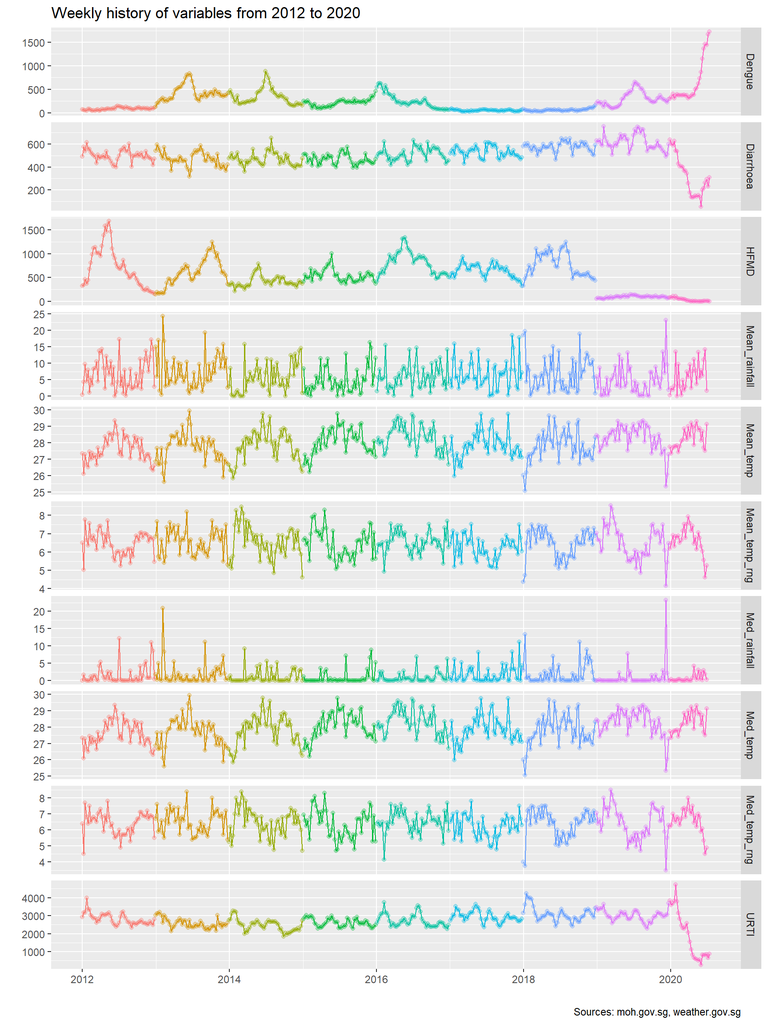

```r
data_time %>%
  dplyr::select(-matches("Epiweek|End")) %>%
  dplyr::mutate(Epiyear = as.factor(Epiyear)) %>%
  tidyr::pivot_longer(Dengue:Med_temp_rng) %>%
  ggplot(aes(x = Start, y = value, color = Epiyear)) +
  geom_line() +
  geom_point(alpha = 0.3) +
  facet_grid(name ~ ., scales = "free_y") +
  labs(title = "Weekly history of variables from 2012 to 2020",
       x = "",
       y = "",
       caption = "Sources: moh.gov.sg, weather.gov.sg") +
  theme(legend.position = "none")
```

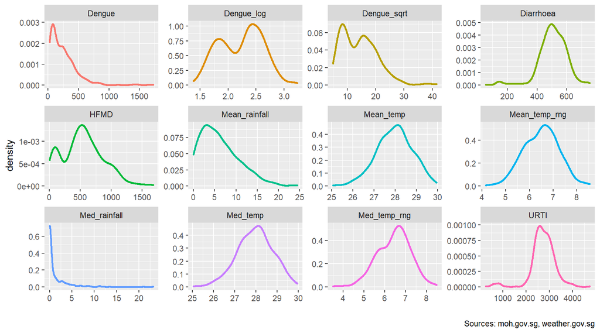

```r
data_time %>%
  dplyr::select(-matches("Epi|End|Start")) %>%
  # Try some transformations
  dplyr::mutate(Dengue_sqrt = sqrt(Dengue),
                Dengue_log = log10(Dengue)) %>%
  tidyr::pivot_longer(everything()) %>%
  ggplot(aes(x = value, color = name)) +
  geom_density(size = 1) +
  facet_wrap(name ~ ., scales = "free") +
  labs(x = "",
       caption = "Sources: moh.gov.sg, weather.gov.sg") +
  theme(legend.position = "none")
```

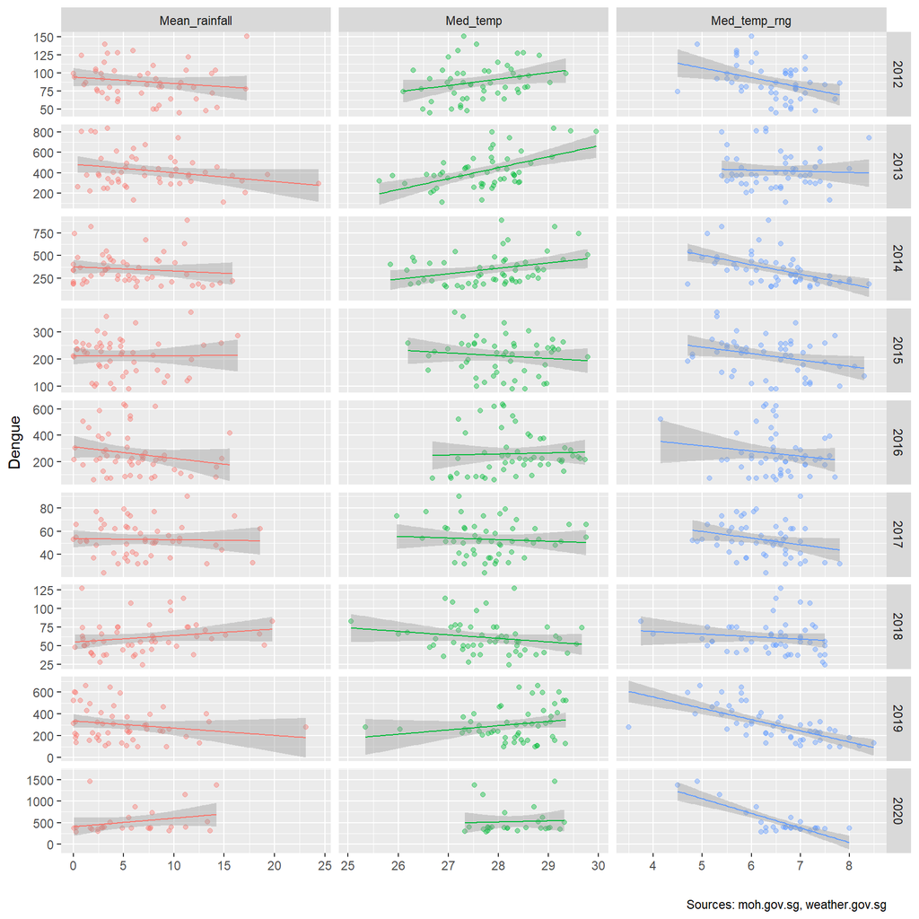

```r
data_time %>%
  dplyr::select(Epiyear, Dengue, Mean_rainfall, Med_temp, Med_temp_rng) %>%
  dplyr::mutate(Dengue = dplyr::lag(Dengue, 1),
                Epiyear = as.factor(Epiyear)) %>%
  tidyr::pivot_longer(Mean_rainfall:Med_temp_rng) %>%
  ggplot(aes(x = value, y = Dengue, color = name)) +
  geom_point(alpha = 0.4) +
  geom_smooth(method = "lm", formula = y ~ x, size = 0.5) +
  facet_grid(Epiyear ~ name, scales = "free") +
  labs(x = "",
       caption = "Sources: moh.gov.sg, weather.gov.sg") +
  theme(legend.position = "none")
```

```r
data_space %>%
  leaflet::leaflet(width = "100%") %>%
  leaflet::addTiles() %>%
  leaflet::addPolygons(
    weight = 1,
    opacity = 1,
    fillOpacity = 0.6,
    smoothFactor = 0.5,
    fillColor = ~leaflet::colorNumeric("Reds", caseden)(caseden),
    label = ~lapply(label, htmltools::HTML),
    popup = ~lapply(label, htmltools::HTML)
  ) %>%
  leaflet::addCircleMarkers(
    data = data$dengue_points,
    color = "red",
    radius = 5,
    fillOpacity = 0.5,
    clusterOptions = leaflet::markerClusterOptions()
  ) %>%
  leaflet::addLabelOnlyMarkers(
    data = sf::st_centroid(data_space),
    label =  ~plan_area,
    labelOptions = leaflet::labelOptions(
      noHide = T,
      textOnly = T,
      direction = "center",
      style = list("color" = "blue"))
  )
```

[interactive chart not shown]

```r
names(data_space)
```

```
 [1] "plan_area"          "ncases"             "nhabs"
 [4] "nclinics"           "pop"                "hdb"
 [7] "one_to_two_rm"      "three_rm"           "four_rm"
[10] "five_rm_exec_flats" "condos_other_apts"  "landed_properties"
[13] "others"             "area_km2"           "mean_rainfall"
[16] "med_rainfall"       "mean_temp"          "med_temp"
[19] "mean_temp_rng"      "med_temp_rng"       "geometry"
[22] "popden"             "caseden"            "label"
```

#### Absolute numbers

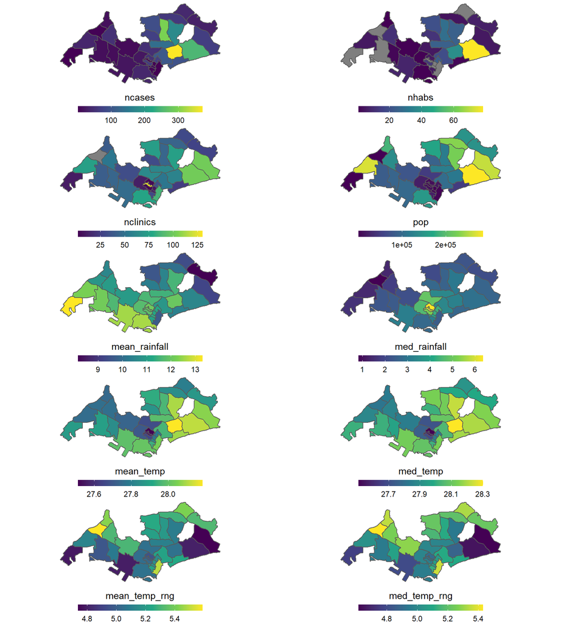

```r
data_space %>%
  dplyr::select(ncases:pop, mean_rainfall:med_temp_rng, geometry) %>%
  gridExtra::grid.arrange(grobs = lapply(list(
    ggplot(aes(fill = ncases), data = .),
    ggplot(aes(fill = nhabs), data = .),
    ggplot(aes(fill = nclinics), data = .),
    ggplot(aes(fill = pop), data = .),
    ggplot(aes(fill = mean_rainfall), data = .),
    ggplot(aes(fill = med_rainfall), data = .),
    ggplot(aes(fill = mean_temp), data = .),
    ggplot(aes(fill = med_temp), data = .),
    ggplot(aes(fill = mean_temp_rng), data = .),
    ggplot(aes(fill = med_temp_rng), data = .)
  ), function(x) {
    x +
      geom_sf() +
      scale_fill_viridis_c(guide = guide_colourbar(
        title.position = "top",
        title.hjust = .5,
        barwidth = 10,
        barheight = .5
      )) +
      theme_void() +
      theme(legend.position = "bottom")
  }), ncol = 2)
```

#### Densities (by area)

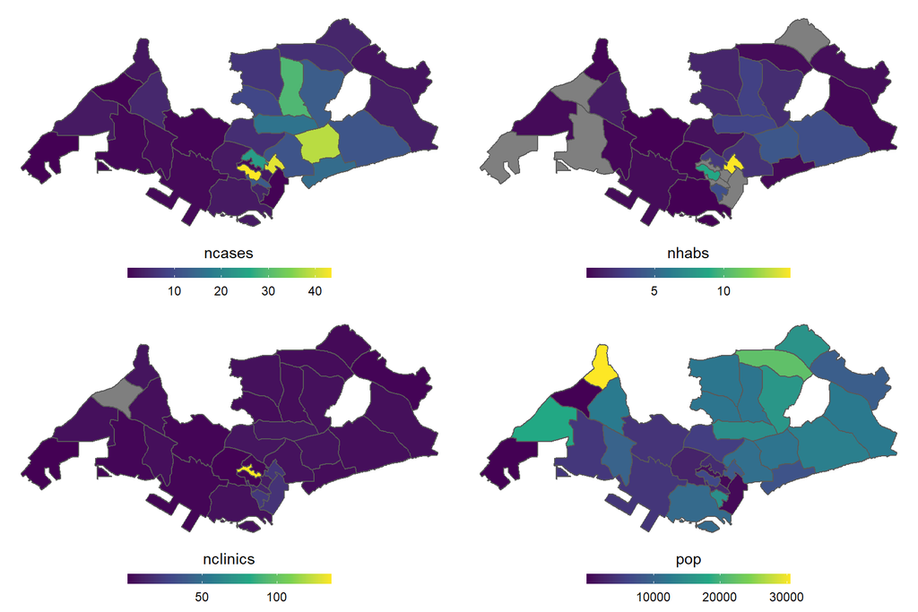

```r
data_space %>%
  dplyr::select(ncases:pop, area_km2, geometry) %>%
  dplyr::mutate_at(dplyr::vars(-geometry), ~(. / area_km2)) %>%
  dplyr::select(-area_km2) %>%
  dplyr::mutate_at(dplyr::vars(-geometry), as.numeric) %>%
  gridExtra::grid.arrange(grobs = lapply(list(
    ggplot(aes(fill = ncases), data = .),
    ggplot(aes(fill = nhabs), data = .),
    ggplot(aes(fill = nclinics), data = .),
    ggplot(aes(fill = pop), data = .)
  ), function(x) {
    x +
      geom_sf() +
      scale_fill_viridis_c(guide = guide_colourbar(
        title.position = "top",
        title.hjust = .5,
        barwidth = 10,
        barheight = .5
      )) +
      theme_void() +
      theme(legend.position = "bottom")
  }), ncol = 2)
```

## Model

For the preparation of the model, we created and ran a correlational matrix, to see how our variables of interest (within the model) are related.

```r
data_time %>%
  # dplyr::select(Dengue:Diarrhoea, Mean_rainfall, Med_temp, Med_temp_rng) %>%
  dplyr::select(Dengue, Mean_rainfall, Med_temp, Med_temp_rng) %>%
  as.matrix() %>%
  Hmisc::rcorr() %>%
  broom::tidy() %>%
  dplyr::filter(p.value < 0.05) %>%
  dplyr::arrange(estimate)
```

```
# A tibble: 3 x 5
  column1      column2       estimate     n   p.value
  <chr>        <chr>            <dbl> <int>     <dbl>
1 Med_temp     Mean_rainfall   -0.499   444 0
2 Med_temp_rng Dengue          -0.151   444 0.00142
3 Med_temp     Dengue           0.201   444 0.0000193
```

We performed mean-centering transformations on all the variables that will be turned into interaction terms.

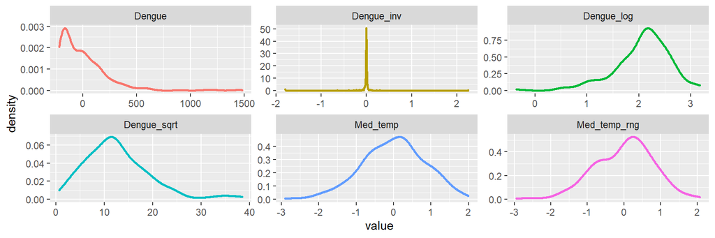

```r
data_time %>%
  dplyr::select(Dengue, Med_temp, Med_temp_rng) %>%
  dplyr::mutate_all(~(. - mean(., na.rm = T))) %>%
  # scale() %>%
  tibble::as_tibble() %>%
  dplyr::mutate(Dengue_sqrt = sqrt(Dengue),
                Dengue_log = log10(Dengue),
                Dengue_inv = (1 / Dengue)) %>%
  tidyr::pivot_longer(everything()) %>%
  ggplot(aes(x = value, color = name)) +
  geom_density(size = 1) +
  facet_wrap(name ~ ., scales = "free") +
  theme(legend.position = "none")
```

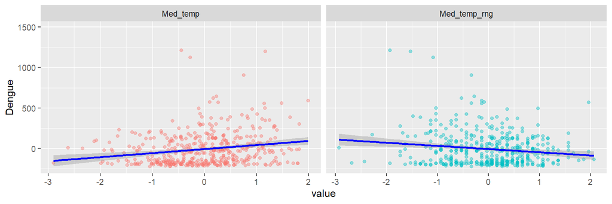

```r
data_time %>%
  dplyr::select(Dengue, Med_temp, Med_temp_rng) %>%
  dplyr::mutate_all(~(. - mean(., na.rm = T))) %>%
  # scale() %>%
  tibble::as_tibble() %>%
  tidyr::pivot_longer(-Dengue) %>%
  ggplot(aes(x = value, y = Dengue, color = name)) +
  geom_point(alpha = 0.4) +
  geom_smooth(method = "lm", formula = y ~ x, color = "blue") +
  facet_grid(. ~ name, scales = "free") +
  theme(legend.position = "none")
```

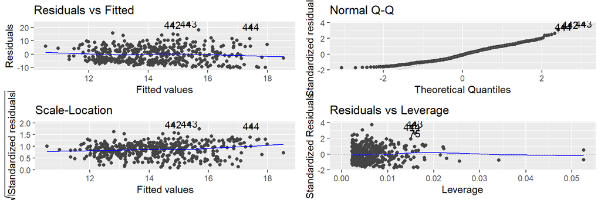

```r
lm(sqrt(Dengue) ~ Med_temp + Med_temp_rng,
   data = data_time %>%
     dplyr::select(Dengue, Med_temp, Med_temp_rng) %>%
     # dplyr::mutate_all(~(. - mean(., na.rm = T))) %>%
     # scale() %>%
     tibble::as_tibble()) %>%
  # summary()
  gvlma::gvlma() %>%
  autoplot()
```

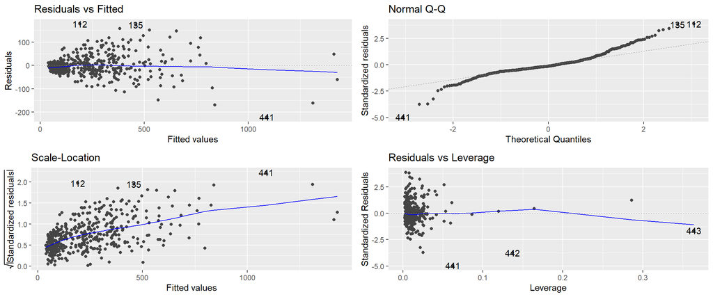

```r
data_time %>%
  dplyr::select(Epiyear, Dengue, Mean_rainfall, Med_temp, Med_temp_rng) %>%
  dplyr::mutate(Dengue_w1 = Dengue,
                Dengue = dplyr::lag(Dengue, 1),
                Epiyear = as.factor(Epiyear)) %>%

  # dplyr::select(-Epiyear) %>%
  # as.matrix() %>%
  # Hmisc::rcorr() %>%
  # broom::tidy() %>%
  # dplyr::filter(p.value < 0.05) %>%
  # dplyr::arrange(estimate)

  # dplyr::select(matches("Epi|Dengue")) %>%
  # tidyr::pivot_longer(Dengue_w1) %>%
  # ggplot(aes(x = value, y = Dengue, color = name)) +
  # geom_point(alpha = 0.4) +
  # geom_smooth(method = "lm", formula = y ~ x) +
  # facet_grid(name ~ Epiyear, scales = "free") +
  # theme(legend.position = "none")

  lm(Dengue ~ Dengue_w1 * (Med_temp + Med_temp_rng), .) %>%
  # gvlma::gvlma()
  autoplot()
```

```r
  # summary()
```